# Chapter 2

## 2.6 Smoothing, Weight Functions and Equivalent Kernels

$$K = \sum ^n_{i=1}\lambda_i \pmb{u}_i \pmb{u}_i^{\top}\\
\bar f = K(K + \sigma_n^2I)^{−1}y
\ \ \ \ (2.35)$$

- linear smoother
- eigendecomposition
- eigenvalue
- eigenvector
- degrees of freedom

but I did not have the 50 repeated measures at give time points (we only have one sample), I could not reproduce figure2.6 for now.

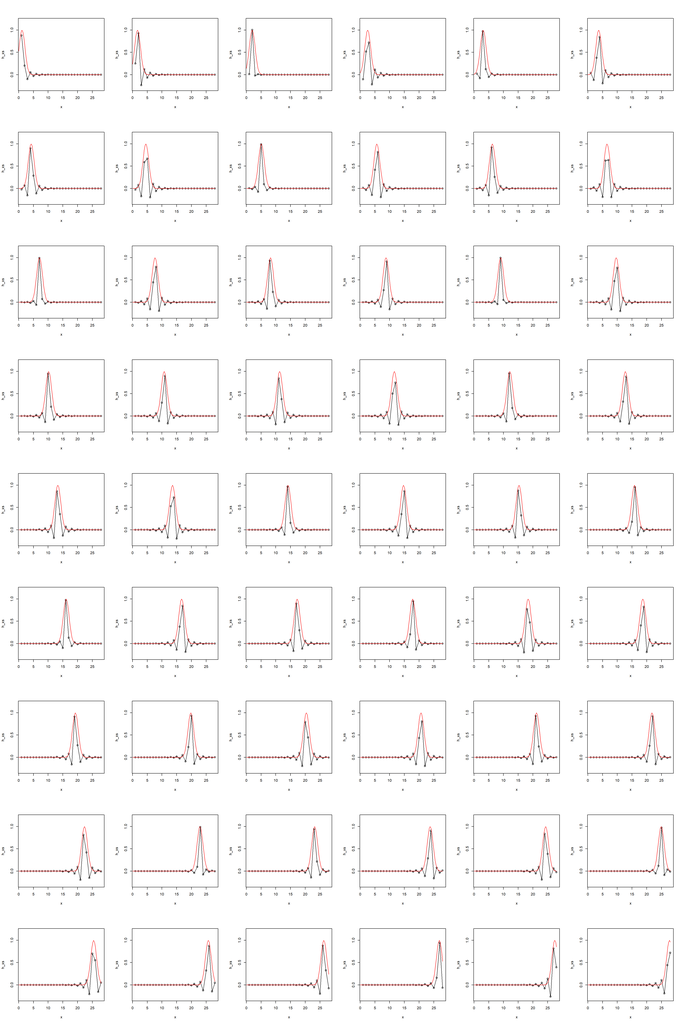

```r
epsilon_n <- 0.1
f <- data.frame(x = progsim_one$daystacked,
                y = progsim_one$prog)
x <- f$x
x_star <- seq(0, 28, len = 100)
k_xx <- get_se_Sigma(x, x, 1)
k_xxs <- get_se_Sigma(x, x_star, 1)
k_xsx <- get_se_Sigma(x_star, x, 1)
k_xsxs <- get_se_Sigma(x_star, x_star, 1)

days <-  seq(1.5, 28, by = 0.5)
op <- par(mfrow = c(9, 6))
for (day in days) {
  k_nrow <- (day - 0) / ((28 - 0) / 100)
  small_k_xs <- k_xsx[k_nrow, ]
  h_xs <-  small_k_xs %*% solve(k_xx)
  plot(x, h_xs, type = "l", ylim = c(-0.3, 1.2))
  points(x, h_xs)
  lines(x_star, k_xsxs[, k_nrow], col = "red")
}
```

```r
par(op)
```

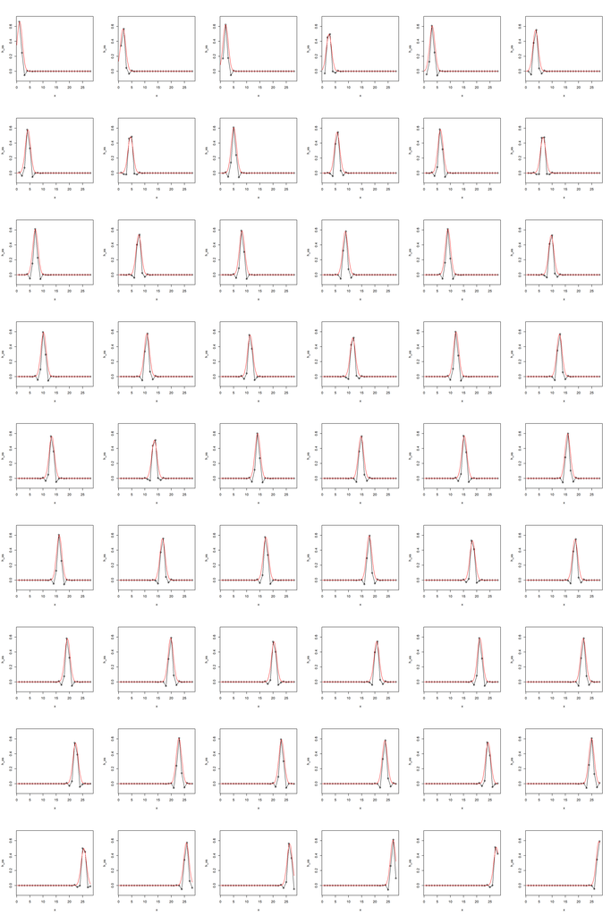

```r
f <- data.frame(x = progsim_one$daystacked,
                y = progsim_one$prog_y)
x <- f$x
n_samples <- 100
x_star <- seq(0, 28, len = 100)
k_xx <- get_se_Sigma(x, x, 1)
k_xxs <- get_se_Sigma(x, x_star, 1)
k_xsx <- get_se_Sigma(x_star, x, 1)
k_xsxs <- get_se_Sigma(x_star, x_star, 1)

op <- par(mfrow = c(9, 6))
for (day in days) {
  k_nrow <- (day - 0) / ((28 - 0) / 100)
  small_k_xs <- k_xxs[, k_nrow]
  h_xs <- solve(k_xx + diag(28, 28) * (epsilon_n)^2) %*% small_k_xs
  ## the k_sse is the kernel,
  ## get rescaled with the max value
  ## of the scale exponential kernels
  k_sse <- k_xsxs[, k_nrow] * max(h_xs)/max(k_xsxs[, k_nrow])
  plot(x, h_xs, type = "l", ylim = c(-0.1, 0.7))
  points(x, h_xs)
  lines(x_star, k_sse, col = "red")
}
```

```r
par(op)
```

$$y = \sum_{i=1}^n\gamma_i\ u_i
\Leftrightarrow\
\gamma_i = u_i^{\top}y\\
\bar f = \sum_{i=1}^n \frac {\gamma_i \lambda_i} {\lambda + \sigma_n^2} u_i
\ \ \ \ (2.36)\\
df=tr\big(K(K + \sigma_n^2I)^{-1}\big) = \sum_{i=1}^n \frac {\lambda_i} {\lambda_i + \sigma^2_n}$$

- **weight function**
- equivalent kernel

$$h(x_*) = (K + \sigma_n^2I)^{−1}k(x_*)\\
\bar f(x_*) = h(x_*)^{\top}y$$

- **kernel smoother**
- Nadaraya-Waston estimator

$$\kappa_i = \kappa(\frac {|x_i − x_*|} {l})\\
\hat f(x_*) = \sum^n_{i=1} w_iy_i\\
w_i = \frac {\kappa_i} {\sum_{j=1}^n \kappa_j}$$

## 2.7* Incorporating Explicit Basis Functions

$$f(x) \sim \mathcal{GP}\big(m(x),\ k(x,\ x')\big)\ \ \ \ (2.37)$$

- fixed/deterministic mean function

$$\bar f_* = \mathbb {\pmb m}(X_*) + K(X_*,\ X)K_y^{−1}(y − \mathbb {\pmb m}(X))
\ \ \ \ (2.38)\\
K_y = K + \sigma_n^2I$$

- stochastic mean function
- polynomial regression

$$g(x) = f(x) + h(x)^{\top}\beta,\\
f(x) \sim \mathcal {GP} \big(0, k(x,\ x')\big)
\ \ \ \ (2.39)$$

$$\beta \sim \mathcal N(b,\ B)\\
g(x) \sim \mathcal {GP}\big(h(x)^{\top}b,\ k(x,\ x') + h(x)^{\top}Bh(x')\big)
\ \ \ \ (2.40)$$

$$\bar \beta = (B^{−1} + HK_y^{−1}H^{\top})^{−1}(HK_y^{−1}y + B^{−1}b),\\
R = H_* − HK_y^{−1}K_*\\
\bar g(X_*) = H_*^{\top}\bar \beta + K_*^{\top}K_y^{−1}(y − H^{\top}\bar \beta) = \bar f(X_*) + R^{\top}\bar \beta\ \ \ \ (2.41a)\\
cov(g_*) = cov(f_*) + R^{\top}(B^{−1} + HK_y^{−1}H^{\top})^{−1}R
\ \ \ \ (2.41b)$$

$$B^{-1} \rightarrow O\\
\bar g(X_*) = \bar f(X_*) + R^{\top}\bar \beta
\ \ \ \ (2.42a)\\
cov(g_*) = cov(f_*) + R^{\top}(HK_y^{-1}H^{\top})^{−1}R
\ \ \ \ (2.42b)\\
\bar \beta = (HK_y^{−1}H^{\top})^{−1}(HK_y^{−1}y),\\$$

#### 2.7.1 Marginal Likelihood

$$log\ p(y|X,\ b,\ B)=−\frac 1 2(H^{\top}b − y)^{\top}(K_y + H^{\top}BH)^{−1}(H^{\top}b − y)
− \frac 1 2 log\ |K_y + H^{\top}BH| − \frac n 2 log\ 2\pi
\ \ \ \ (2.43)$$

$$log\ p(y|X,\ b=0,\ B)=−\frac 1 2 y^{\top}K_y^{−1}y + \frac 1 2 y^{\top}Cy −
\frac 1 2 log\ |K_y| − \frac 1 2 log\ |B| − \frac 1 2 log\ |A| − \frac n 2 log\ 2\pi
\ \ \ \ (2.44)\\
A = B^{−1} + HK^{−1}_y H^{\top}\\
C = K_y^{−1}H^{\top}A^{−1}HK_y^{−1}$$

Let the rank of $H^{\top}$ be $m$. Then as shown in *Ansley and Kohn [1985]* this means that we must discard the terms $−\frac 1 2 log\ |B| − \frac m 2 log\ 2\pi$ from *eq. (2.44)*

$$log\ p(y|X) = −\frac 1 2 y^{\top}K_y^{−1}y + \frac 1 2 y^{\top}Cy − \frac 1 2 log\ |K_y| − \frac 1 2 log\ |A| − \frac {n−m} 2 log\ 2\pi
\ \ \ \ (2.45)\\
A = HK^{−1}_y H^{\top}\\
C = K_y^{−1}H^{\top}A^{−1}HK_y^{−1}$$

## 2.8 History and Related Work

- time series
- geostatistics
- kriging
- SVM support vector machine
- RVM relevance vector machine

## 2.9 Exercise

the variance and bias trade-off

### matrix

$$X=A\B\ \ \ \Leftrightarrow \ \ \ AX=B\\
\Phi(C)^{\top}\Sigma_p\Phi(D)=K(C,\ D) \\$$